# Alternativa Prueba

ags

08-10-2021

Ambos deberán hacer el ejercicio en grupo en base a los datos de “DP76 - Avance en Campaña de Vacunación COVID-19: Descripción”. Estos ejercicios están disponibles en la clase y pueden ser obtenidos desde ahí.

- Primer grupo: Pablo y Jessica
- Segundo grupo: Ismael, Lucas e Ignacio

## Grupo 1

La base de datos a utilizar para su grupo es la siguiente:

```r
#Cargamos los paquetes estadísticos. Si no existen en su computador, los instala
if(!require(dplyr)){install.packages("dplyr")}
if(!require(readr)){install.packages("readr")}
if(!require(knitr)){install.packages("knitr")}
if(!require(kableExtra)){install.packages("kableExtra")}
if(!require(data.table)){install.packages("data.table")}
if(!require(highcharter)){install.packages("highcharter")}

#Primer grupo: Pablo y Jessica
dp76_1<- readr::read_csv("https://raw.githubusercontent.com/MinCiencia/Datos-COVID19/master/output/producto76/fabricante_std.csv") %>%
  #Sólo seleccionaremos las segundas dosis
  dplyr::filter(Dosis=="Segunda") %>%
  #borraremos la columna "dosis"
  dplyr::select(-Dosis)%>%
  #Dividiremos la cantidad en cifras de mil
  dplyr::mutate(Cantidad=Cantidad/1000) %>%
  #descartamos los recuentos totales
  dplyr::filter(Fabricante!="Total") %>%
  #Seleccionamos datos hasta el 02 de Octubre de 2021
  dplyr::filter(Fecha<="2021-10-02")
```

## Grupo 2

La base de datos a utilizar para su grupo es la siguiente:

```r
#Cargamos los paquetes estadísticos. Si no existen en su computador, los instala
if(!require(dplyr)){install.packages("dplyr")}
if(!require(readr)){install.packages("readr")}
if(!require(knitr)){install.packages("knitr")}
if(!require(kableExtra)){install.packages("kableExtra")}
if(!require(data.table)){install.packages("data.table")}
if(!require(highcharter)){install.packages("highcharter")}

#Segundo grupo: Ismael, Lucas e Ignacio
dp76_2<- readr::read_csv("https://raw.githubusercontent.com/MinCiencia/Datos-COVID19/master/output/producto76/fabricante_std.csv") %>%
  #Sólo seleccionaremos las segundas dosis
  dplyr::filter(Dosis=="Primera") %>%
  #borraremos la columna "dosis"
  dplyr::select(-Dosis) %>%
  #Dividiremos la cantidad en cifras de mil
  dplyr::mutate(Cantidad=Cantidad/1000)%>%
  #descartamos los recuentos totales
  dplyr::filter(Fabricante!="Total") %>%
  #Seleccionamos datos hasta el 02 de Octubre de 2021
  dplyr::filter(Fecha<="2021-10-02")
```

### 1. Ambos grupos, genere un resumen de los datos asignados a su grupo completando los campos demarcados en “____________”

```r
#Describimos los datos
psych::describeBy(dp76_1, group="____________", mat=T) %>%
  #Los hacemos en formato data.table, para conservar el nombre de las filas
  data.table::data.table(keep.rownames=T) %>%
  #Filtramos la fecha, porque no aporta información
  dplyr::filter(!grepl("Fecha", rn)) %>%
  knitr::kable(.,format ='html', format.args = list(decimal.mark = '.', big.mark = ','),
               caption='Tabla 1. Descripción de variables según Fabricante',
               align =c('l','c',rep('c', 101))) %>%
  kableExtra::kable_styling(bootstrap_options = c('striped', 'hover'),font_size = 10) %>%
  kableExtra::scroll_box(width = '100%', height = '300px')
```

### 2. Genere una tabla de frecuencias para la medida con 12 intervalos para el primer grupo, 11 para el segundo, completando la sintaxis en los campos demarcados, en base a los datos asignados a su grupo. Complete la sintaxis para generar una tabla html

```r
#####sort ordena los datos de acuerdo al vector de cantidad
invisible("Complete la sintaxis ...")
cbind.data.frame(y=dp76_"_"[order(dp76_"_"$Cantidad),"Cantidad"], #conservar la variable continua original por el momento
                 #cut discretiza datos numéricos en rangos, en una secuencia de los datos Y, de acuerdo a la cantidad de clases sugeridas
                 y_interval= factor(cut(as.numeric(unlist(dp76_"_"[order(dp76_"_"$Cantidad),"_______"])),
                                        breaks="_________", dig.lab=6),ordered=T)) %>% #dig.lab, para que no genere formatos numericos con notacion científica
  #Grupos ordenados --> ordered T
  #Agrupamos los datos de acuerdo a los intervalos y contamos la frecuencia
  dplyr::group_by("______________") %>%
  dplyr::count() %>%
  dplyr::ungroup() %>%
  dplyr::mutate(f_i=round(n/sum(n),2),
                N_i=cumsum(n),
                F_i=round(cumsum(n)/sum(n),2)) %>%
  data.frame() %>%
  invisible("Complete la sintaxis haciendo una tabla como la presentada en clases y talleres...")
```

Debiese llegar a una tabla del tipo:

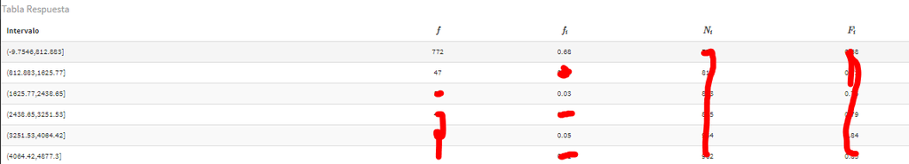

```r
knitr::include_graphics('./img/prueba_alt_tab_freq.png')
```

### 3. Argumente la validez de mi afirmación: ‘Si dividimos en 12 las cantidades entregadas de vacunas por día para la segunda dosis, los días en los que se administraron entre (4877.3,5690.18] dosis/1,000 hab son los menos frecuentes’ (grupo 1)

### 3. Argumente la validez de mi afirmación: ‘Si dividimos en 11 las cantidades entregadas de vacunas por día para la primera dosis, los días en los que se administraron entre (4013.5,5016.88] dosis/1,000 hab son los menos frecuentes’ (grupo 2)

## Ambos grupos:

### 4. Genere un diagrama de cajas por fabricante

### 5. Mire el diagrama de cajas obtenido, particularmente el grupo al que se le administró Pfizer. ¿Está sesgado a la izquierda o a la derecha?, ¿Y Sinovac?

### 6. ¿La distribución para 5. es simétrica o sesgada asimétrica?, si está sesgada, ¿lo está de forma positiva o negativa?, argumente

### 7. Calcule los percentiles 43 y 89 de la cantidad de vacunas para cada grupo. Indíquelos

### 8. Encuentre los valores z de 500 y 200 para el grupo al que se administró Sinovac (use `subset` de ser necesario)

### 9. Asumiendo una distribución normal, indique a cuantas desviaciones estándar de la media se encuentran los valores obtenidos en 8.

### 10. Indique adicionalmente la media, la mediana y la desviación estándar de cada grupo (Fabricante)